# Time Series Analysis

**Md. Mostakim**  
Student of Applied Statistics and Data Science  
Institute of Applied Statistics and Data Science  
University of Dhaka

[figure not shown]

# Welcome

# What this presentation covers

This presentation develops a practical workflow for time series analysis in R:

| Stage | Main idea | R tools |
| --- | --- | --- |
| 1 | Explore the series | `print()`, `head()`, `tail()`, `plot()` |
| 2 | Understand time structure | `start()`, `end()`, `frequency()`, `cycle()` |
| 3 | Build time series objects | `ts()` |
| 4 | Handle missing values and trends | `NA`, `log()`, `diff()` |
| 5 | Understand stationarity | WN, RW, weak stationarity |
| 6 | Measure dependence | covariance, correlation, ACF |
| 7 | Model dependence | AR and MA models |
| 8 | Forecast | `predict()`, prediction intervals |
| 9 | Compare models | AIC, BIC, fitted values |

> **Learning goal:** By the end, you should be able to inspect a time series, identify important features, transform it when appropriate, interpret ACF behavior, fit simple AR/MA models, and evaluate forecasts.

# A simple mental model

**Observe → Diagnose → Transform → Model → Validate → Forecast**

This sequence is more important than memorizing individual R commands.

# Quick reference

**White noise:** stationary, unpredictable, no serial correlation.

**Random walk:** non-stationary, strongly dependent on the past.

**AR model:** today’s value depends on previous values.

**MA model:** today’s value depends on current and past shocks.

**ACF:** measures dependence between a series and its lagged values.

**Differencing:** focuses on changes and can remove trend or seasonality.

# Exploring raw time series

The most common first step when conducting time series analysis is to display your time series dataset in a visually intuitive format. The most useful way to view raw time series data in R is to use the `print()` command, which displays the `Start`, `End`, and `Frequency` of your data along with the observations.

Another useful command for viewing time series data in R is the `length()` function, which tells you the total number of observations in your data.

Some datasets are very long, and previewing a subset of data is more suitable than displaying the entire series. The `head(___, n =___)` and `tail(___, n =___)` functions, in which n is the number of items to display, focus on the first and last few elements of a given dataset respectively.

In this exercise, you’ll explore the famous River Nile annual streamflow data, `Nile`. This time series dataset includes some metadata information. When calling `print(Nile)`, note that `Start = 1871` indicates that 1871 is the year of the first annual observation, and `End = 1970` indicates 1970 is the year of the last annual observation

```r
# Print the Nile dataset
print(Nile)
```

```
## Time Series:
## Start = 1871
## End = 1970
## Frequency = 1
##   [1] 1120 1160  963 1210 1160 1160  813 1230 1370 1140  995  935 1110  994 1020
##  [16]  960 1180  799  958 1140 1100 1210 1150 1250 1260 1220 1030 1100  774  840
##  [31]  874  694  940  833  701  916  692 1020 1050  969  831  726  456  824  702
##  [46] 1120 1100  832  764  821  768  845  864  862  698  845  744  796 1040  759
##  [61]  781  865  845  944  984  897  822 1010  771  676  649  846  812  742  801
##  [76] 1040  860  874  848  890  744  749  838 1050  918  986  797  923  975  815
##  [91] 1020  906  901 1170  912  746  919  718  714  740
```

```r
# List the number of observations in the Nile dataset
length(Nile)
```

```
## [1] 100
```

```r
# Display the first 10 elements of the Nile dataset
head(Nile, n = 10)
```

```
## Time Series:
## Start = 1871
## End = 1880
## Frequency = 1
##  [1] 1120 1160  963 1210 1160 1160  813 1230 1370 1140
```

```r
# Display the last 12 elements of the Nile dataset
tail(Nile, n = 12)
```

```
## Time Series:
## Start = 1959
## End = 1970
## Frequency = 1
##  [1]  975  815 1020  906  901 1170  912  746  919  718  714  740
```

# Basic time series plots

While simple commands such as `print()`, `length()`, `head()`, and `tail()` provide crucial information about your time series data, another very useful way to explore any data is to generate a plot.

In this exercise, you will plot the River Nile annual streamflow data using the `plot()` function. For time series data objects such as `Nile`, a `Time` index for the horizontal axis is typically included. From the previous exercise, you know that this data spans from 1871 to 1970, and horizontal tick marks are labeled as such. The default label of `"Time"` is not very informative. Since these data are annual measurements, you should use the label `"Year"`. While you’re at it, you should change the vertical axis label to `"River Volume (1e9 m^{3})"`.

Additionally, it helps to have an informative title, which can be set using the argument `main`. For your purposes, a useful title for this figure would be “Annual River Nile Volume at Aswan, 1871-1970”.

Finally, the default plotting `type` for time series objects is `"l"` for line. Connecting consecutive observations can help make a time series plot more interpretable. Sometimes it is also useful to include both the observations points as well as the lines, and we instead use `"b"` for both.

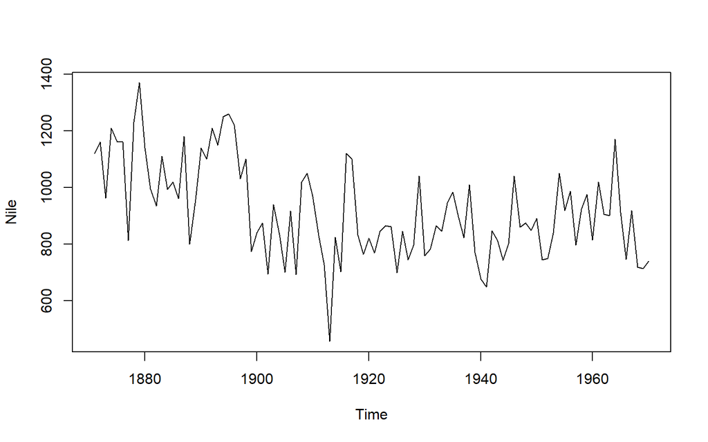

```r
# Plot the Nile data
plot(Nile)
```

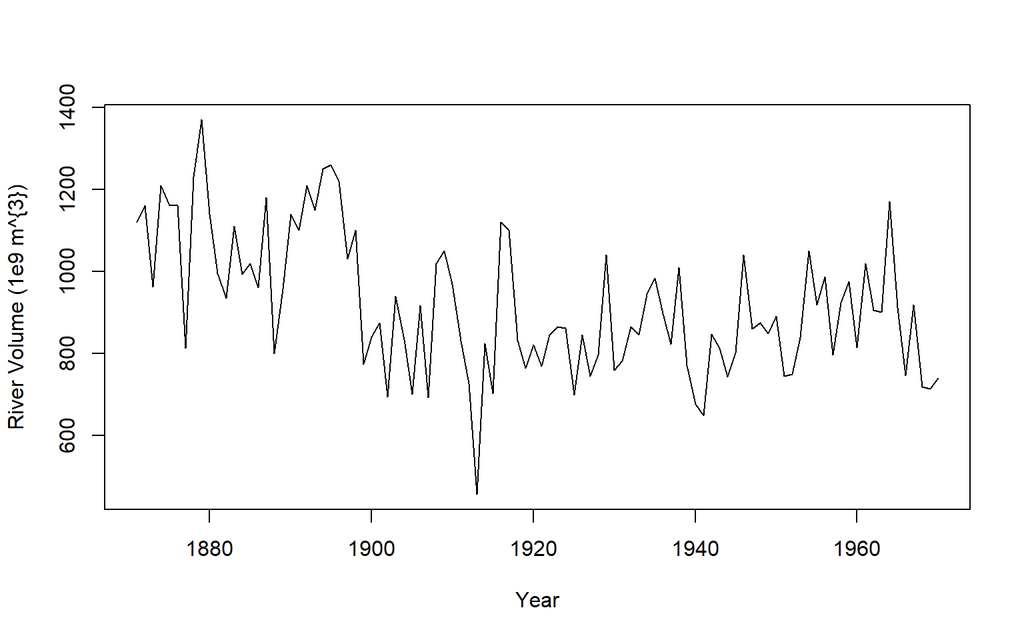

```r
# Plot the Nile data with xlab and ylab arguments
plot(Nile, xlab = "Year", ylab = "River Volume (1e9 m^{3})")
```

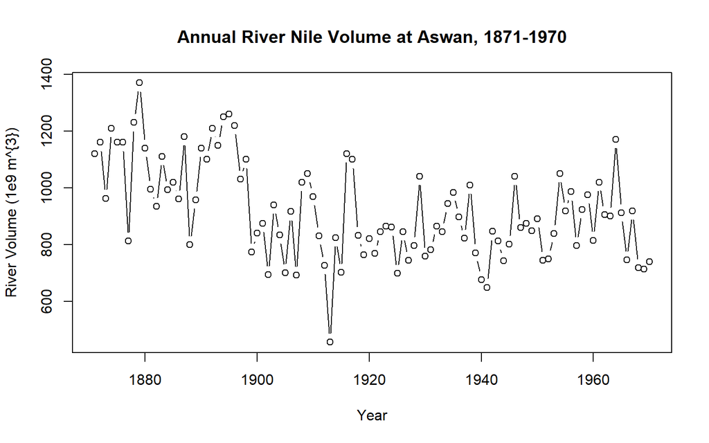

```r
# Plot the Nile data with xlab, ylab, main, and type arguments

plot(Nile, xlab = "Year", ylab = "River Volume (1e9 m^{3})",
main = "Annual River Nile Volume at Aswan, 1871-1970",
type = "b")
```

# What does the time index tell us?

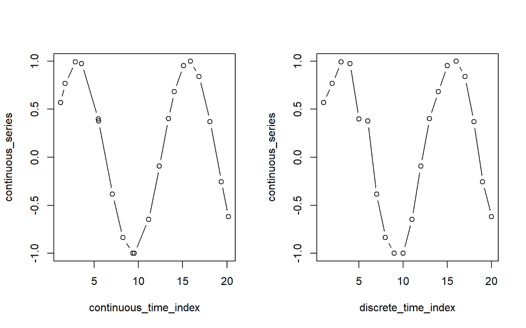

```r
continuous_series <- c(
  0.56889468,  0.76630408,  0.99207512,  0.97481741,  0.39912320,  0.37660246,
 -0.38532033, -0.83635852, -0.99966983, -0.99831019, -0.64622280, -0.09386151,
  0.40052909,  0.68160578,  0.95318159,  0.99693803,  0.83934194,  0.37003754,
 -0.25509676, -0.61743983
)

continuous_time_index <- c(
   1.210322,  1.746137,  2.889634,  3.591384,  5.462065,  5.510933,  7.074295,
   8.264398,  9.373382,  9.541063, 11.161122, 12.378371, 13.390559, 14.066280,
  15.093547, 15.864515, 16.857413, 18.091457, 19.365451, 20.180524
)

# Plot the continuous_series using continuous time indexing
par(mfrow=c(1,2))
plot(continuous_time_index,continuous_series, type = "b")

# Make a discrete time index using 1:20
discrete_time_index <- 1:20

# Now plot the continuous_series using discrete time indexing
plot(discrete_time_index,continuous_series, type = "b")
```

# Key takeaway

The **frequency** tells you how many observations occur per unit of time.

- Annual data → `frequency = 1`
- Quarterly data → `frequency = 4`
- Monthly data → `frequency = 12`

> **Exam tip:** Always check `start()`, `end()`, and `frequency()` before interpreting a time series plot.

# Sampling Frequency

# Identifying the sampling frequency

In addition to viewing your data and plotting over time, there are several additional operations that can be performed on time series datasets.

The `start()` and `end()` functions return the time index of the first and last observations, respectively. The `time()` function calculates a vector of time indices, with one element for each time index on which the series was observed.

The `deltat()` function returns the fixed time interval between observations and the `frequency()` function returns the number of observations per unit time. Finally, the `cycle()` function returns the position in the cycle of each observation.

In this exercise, you’ll practice applying these functions to the `AirPassengers` dataset, which reports the monthly total international airline passengers (in thousands) from 1949 to 1960.

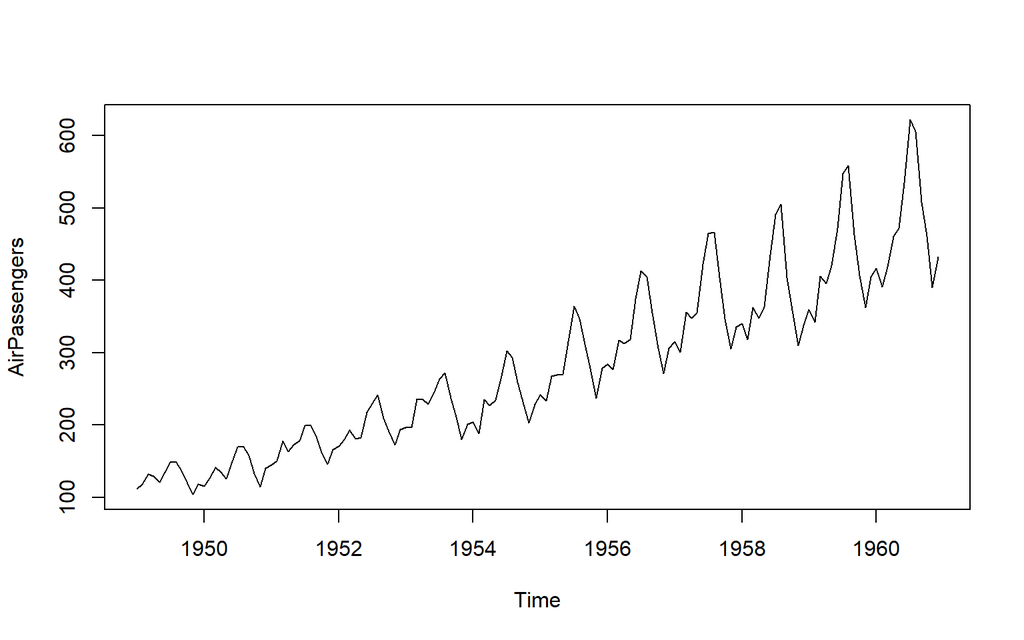

```r
# Plot AirPassengers
plot(AirPassengers)
```

```r
# View the start and end dates of AirPassengers
start(AirPassengers)
```

```
## [1] 1949    1
```

```r
end(AirPassengers)
```

```
## [1] 1960   12
```

```r
# Use time(), deltat(), frequency(), and cycle() with AirPassengers

time(AirPassengers)
```

```
##           Jan      Feb      Mar      Apr      May      Jun      Jul      Aug
## 1949 1949.000 1949.083 1949.167 1949.250 1949.333 1949.417 1949.500 1949.583
## 1950 1950.000 1950.083 1950.167 1950.250 1950.333 1950.417 1950.500 1950.583
## 1951 1951.000 1951.083 1951.167 1951.250 1951.333 1951.417 1951.500 1951.583
## 1952 1952.000 1952.083 1952.167 1952.250 1952.333 1952.417 1952.500 1952.583
## 1953 1953.000 1953.083 1953.167 1953.250 1953.333 1953.417 1953.500 1953.583
## 1954 1954.000 1954.083 1954.167 1954.250 1954.333 1954.417 1954.500 1954.583
## 1955 1955.000 1955.083 1955.167 1955.250 1955.333 1955.417 1955.500 1955.583
## 1956 1956.000 1956.083 1956.167 1956.250 1956.333 1956.417 1956.500 1956.583
## 1957 1957.000 1957.083 1957.167 1957.250 1957.333 1957.417 1957.500 1957.583
## 1958 1958.000 1958.083 1958.167 1958.250 1958.333 1958.417 1958.500 1958.583
## 1959 1959.000 1959.083 1959.167 1959.250 1959.333 1959.417 1959.500 1959.583
## 1960 1960.000 1960.083 1960.167 1960.250 1960.333 1960.417 1960.500 1960.583
##           Sep      Oct      Nov      Dec
## 1949 1949.667 1949.750 1949.833 1949.917
## 1950 1950.667 1950.750 1950.833 1950.917
## 1951 1951.667 1951.750 1951.833 1951.917
## 1952 1952.667 1952.750 1952.833 1952.917
## 1953 1953.667 1953.750 1953.833 1953.917
## 1954 1954.667 1954.750 1954.833 1954.917
## 1955 1955.667 1955.750 1955.833 1955.917
## 1956 1956.667 1956.750 1956.833 1956.917
## 1957 1957.667 1957.750 1957.833 1957.917
## 1958 1958.667 1958.750 1958.833 1958.917
## 1959 1959.667 1959.750 1959.833 1959.917
## 1960 1960.667 1960.750 1960.833 1960.917
```

```r
deltat(AirPassengers)
```

```
## [1] 0.08333333
```

```r
frequency(AirPassengers)
```

```
## [1] 12
```

```r
cycle(AirPassengers)
```

```
##      Jan Feb Mar Apr May Jun Jul Aug Sep Oct Nov Dec
## 1949   1   2   3   4   5   6   7   8   9  10  11  12
## 1950   1   2   3   4   5   6   7   8   9  10  11  12
## 1951   1   2   3   4   5   6   7   8   9  10  11  12
## 1952   1   2   3   4   5   6   7   8   9  10  11  12
## 1953   1   2   3   4   5   6   7   8   9  10  11  12
## 1954   1   2   3   4   5   6   7   8   9  10  11  12
## 1955   1   2   3   4   5   6   7   8   9  10  11  12
## 1956   1   2   3   4   5   6   7   8   9  10  11  12
## 1957   1   2   3   4   5   6   7   8   9  10  11  12
## 1958   1   2   3   4   5   6   7   8   9  10  11  12
## 1959   1   2   3   4   5   6   7   8   9  10  11  12
## 1960   1   2   3   4   5   6   7   8   9  10  11  12
```

# Basic time series object

# Creating a time series object with ts()

The function `ts()` can be applied to create time series objects. A time series object is a vector (univariate) or matrix (multivariate) with additional attributes, including time indices for each observation, the sampling frequency and time increment between observations, and the cycle length for periodic data. Such objects are of the ts class, and represent data that has been observed at (approximately) equally spaced time points. Now you will create time series objects yourself.

The advantage of creating and working with time series objects of the `ts` class is that many methods are available for utilizing time series attributes, such as time index information. For example, as you’ve seen in earlier exercises, calling `plot()` on a `ts` object will automatically generate a plot over time.

In this exercise, you’ll familiarize yourself with the ts class by encoding some time series data (saved as `data_vector`) into ts and exploring the result. Your time series `data_vector` starts in the year 2004 and has 4 observations per year (i.e. it is quarterly data).

```r
data_vector <- c(
   2.0521941073,  4.2928852797,  3.3294132944,  3.5085950670,  0.0009576938,
   1.9217186345,  0.7978134128,  0.2999543435,  0.9435687536,  0.5748283388,
  -0.0034005903,  0.3448649176,  2.2229761136,  0.1763144576,  2.7097622770,
   1.2501948965, -0.4007164754,  0.8852732121, -1.5852420266, -2.2829278891,
  -2.5609531290, -3.1259963754, -2.8660295895, -1.7847009207, -1.8894912908,
  -2.7255351194, -2.1033141800, -0.0174256893, -0.3613204151, -2.9008403327,
  -3.2847440927, -2.8684594718, -1.9505074437, -4.8801892525, -3.2634605353,
  -1.6396062522, -3.3012575840, -2.6331245433, -1.7058354022, -2.2119825061,
  -0.5170595186,  0.0752508095, -0.8406994716, -1.4022683487, -0.1382114230,
  -1.4065954703, -2.3046941055,  1.5073891432,  0.7118679477, -1.1300519022
)
```

```r
# Use print() and plot() to view data_vector
print(data_vector)
```

```
##  [1]  2.0521941073  4.2928852797  3.3294132944  3.5085950670  0.0009576938
##  [6]  1.9217186345  0.7978134128  0.2999543435  0.9435687536  0.5748283388
## [11] -0.0034005903  0.3448649176  2.2229761136  0.1763144576  2.7097622770
## [16]  1.2501948965 -0.4007164754  0.8852732121 -1.5852420266 -2.2829278891
## [21] -2.5609531290 -3.1259963754 -2.8660295895 -1.7847009207 -1.8894912908
## [26] -2.7255351194 -2.1033141800 -0.0174256893 -0.3613204151 -2.9008403327
## [31] -3.2847440927 -2.8684594718 -1.9505074437 -4.8801892525 -3.2634605353
## [36] -1.6396062522 -3.3012575840 -2.6331245433 -1.7058354022 -2.2119825061
## [41] -0.5170595186  0.0752508095 -0.8406994716 -1.4022683487 -0.1382114230
## [46] -1.4065954703 -2.3046941055  1.5073891432  0.7118679477 -1.1300519022
```

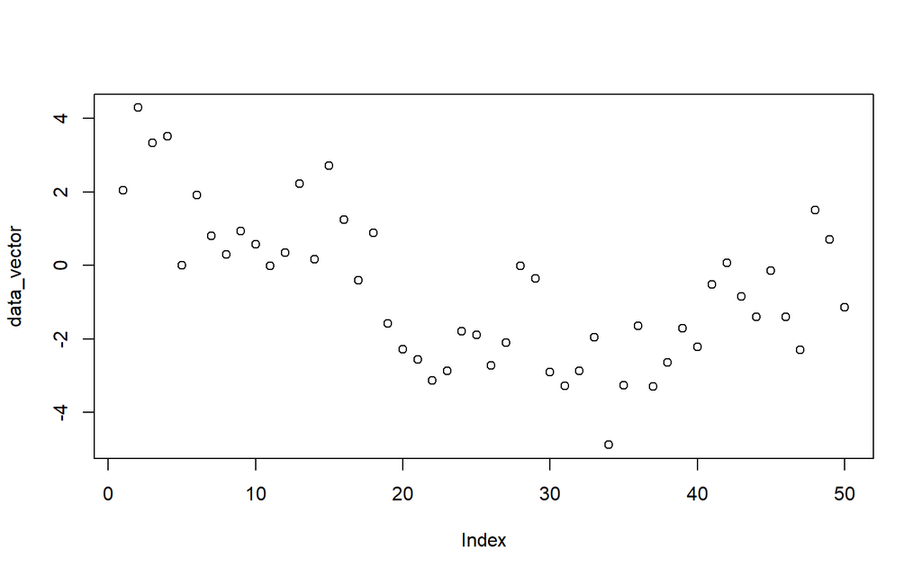

```r
plot(data_vector)
```

```r
# Convert data_vector to a ts object with start = 2004 and frequency = 4
time_series <- ts(data_vector, start = c(2004, 1), frequency = 4)

# Use print() and plot() to view time_series
print(time_series)
```

```
##               Qtr1          Qtr2          Qtr3          Qtr4
## 2004  2.0521941073  4.2928852797  3.3294132944  3.5085950670
## 2005  0.0009576938  1.9217186345  0.7978134128  0.2999543435
## 2006  0.9435687536  0.5748283388 -0.0034005903  0.3448649176
## 2007  2.2229761136  0.1763144576  2.7097622770  1.2501948965
## 2008 -0.4007164754  0.8852732121 -1.5852420266 -2.2829278891
## 2009 -2.5609531290 -3.1259963754 -2.8660295895 -1.7847009207
## 2010 -1.8894912908 -2.7255351194 -2.1033141800 -0.0174256893
## 2011 -0.3613204151 -2.9008403327 -3.2847440927 -2.8684594718
## 2012 -1.9505074437 -4.8801892525 -3.2634605353 -1.6396062522
## 2013 -3.3012575840 -2.6331245433 -1.7058354022 -2.2119825061
## 2014 -0.5170595186  0.0752508095 -0.8406994716 -1.4022683487
## 2015 -0.1382114230 -1.4065954703 -2.3046941055  1.5073891432
## 2016  0.7118679477 -1.1300519022
```

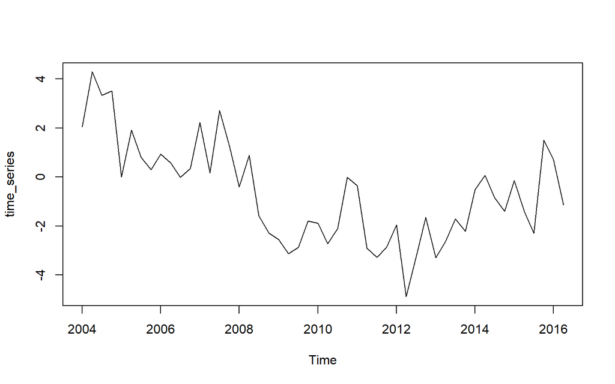

```r
plot(time_series)
```

**Breakdown of the *start = c(1949, 1)* Syntax**

The c(1949, 1) part is a vector with two specific arguments:

- The First Number (1949): Represents the major time unit, which is the calendar year.
- The Second Number (1): Represents the minor time unit, which is the cycle/period within that year.

*Examples Based on Frequency*

The meaning of that second number changes depending on the frequency you set for your data:

- **Monthly** (frequency = 12): c(1949, 1) means January 1949. If you wrote c(1949, 6), it would mean June 1949.
- **Quarterly** (frequency = 4): c(1949, 1) means Quarter 1 (Jan-Mar) of 1949. If you wrote c(1949, 3), it would mean Quarter 3.
- **Weekly** (frequency = 52): c(1949, 1) means Week 1 of 1949.

# Testing whether an object is a time series

When you use datasets from others, such as those included in an R package, you can check whether they are ts objects using the `is.ts()` command. The result of the test is either `TRUE` when the data is of the ts class, or `FALSE` if it is not.

In this exercise, you’ll explore the class of the datasets you’ve been using throughout this chapter.

```r
# Check whether data_vector and time_series are ts objects
is.ts(data_vector)
```

```
## [1] FALSE
```

```r
is.ts(time_series)
```

```
## [1] TRUE
```

```r
# Check whether Nile is a ts object
is.ts(Nile)
```

```
## [1] TRUE
```

```r
# Check whether AirPassengers is a ts object

is.ts(AirPassengers)
```

```
## [1] TRUE
```

# Plotting a time series object

It is often very useful to plot data we are analyzing, as is the case when conducting time series analysis. If the dataset under study is of the `ts` class, then the `plot()` function has methods that automatically incorporate time index information into a figure.

Let’s consider the `eu_stocks` dataset (available in R by default as `EuStockMarkets`). This dataset contains daily closing prices of major European stock indices from 1991-1998, specifically, from Germany (`DAX`), Switzerland (`SMI`), France (`CAC`), and the UK (`FTSE`). The data were observed when the markets were open, so there are no observations on weekends and holidays. We will proceed with the approximation that this dataset has evenly spaced observations and is a four dimensional time series.

To conclude this chapter, this exercise asks you to apply several of the functions you’ve already learned to this new dataset.

```r
eu_stocks <- EuStockMarkets

# Check whether eu_stocks is a ts object
is.ts(eu_stocks)
```

```
## [1] TRUE
```

```r
# View the start, end, and frequency of eu_stocks
start(eu_stocks)
```

```
## [1] 1991  130
```

```r
end(eu_stocks)
```

```
## [1] 1998  169
```

```r
frequency(eu_stocks)
```

```
## [1] 260
```

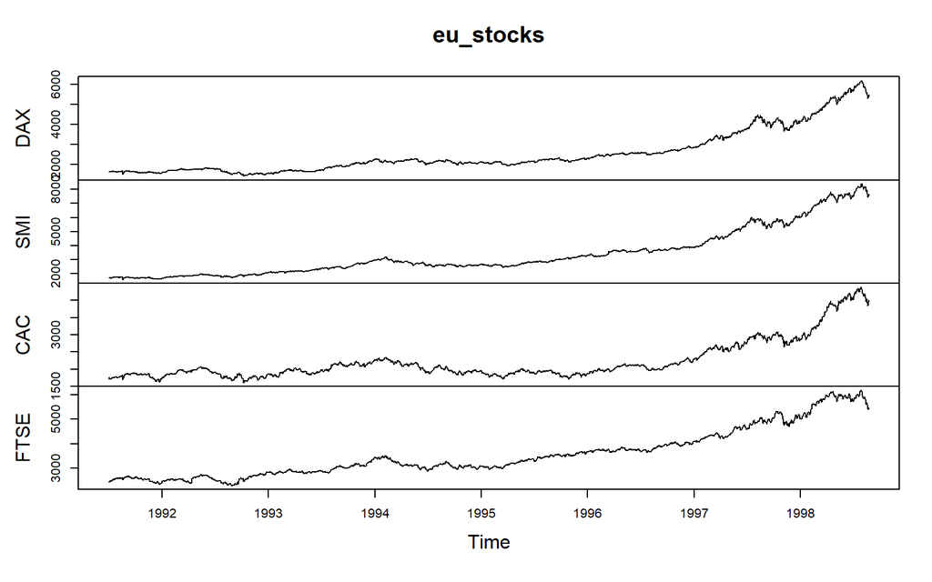

```r
# Generate a simple plot of eu_stocks

plot(eu_stocks)
```

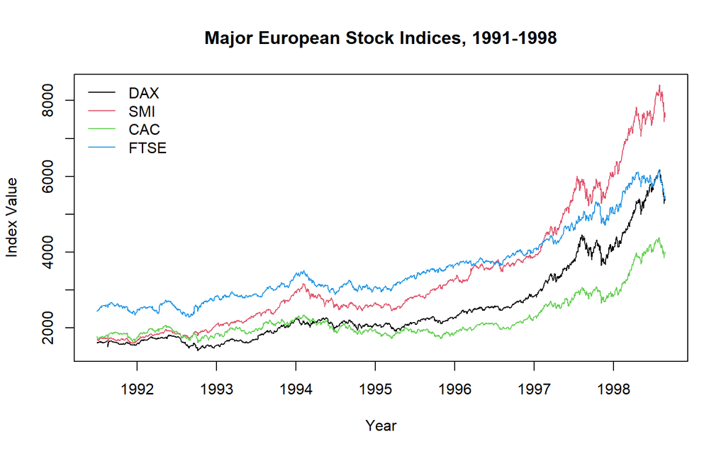

```r
# Use ts.plot with eu_stocks
ts.plot(eu_stocks, col = 1:4, xlab = "Year", ylab = "Index Value",
        main = "Major European Stock Indices, 1991-1998")

# Add a legend to your ts.plot
legend("topleft", colnames(eu_stocks), lty = 1, col = 1:4, bty = "n")
```

# Missing values

```r
# 1. Combine the monthly data into a single continuous vector
air_data <- c(
  112, 118, 132, 129, 121, 135, 148, 148, 136, 119, 104, 118, # 1949
  115, 126, 141, 135, 125, 149, 170, 170, 158, 133, 114, 140, # 1950
  145, 150, 178, 163, 172, 178, 199, 199, 184, 162, 146, 166, # 1951
  171, 180, 193, 181, 183, 218, 230, 242, 209, 191, 172, 194, # 1952
  196, 196, 236, 235, 229, 243, 264, 272, 237, 211, 180, 201, # 1953
  204, 188, 235, 227, 234, 264, 302, 293, 259, 229, 203, 229, # 1954
  242, 233, 267, 269, 270, 315, 364, 347, 312, 274, 237, 278, # 1955
   NA,  NA,  NA,  NA,  NA,  NA,  NA,  NA,  NA,  NA,  NA,  NA, # 1956 (Missing year)
  315, 301, 356, 348, 355, 422, 465, 467, 404, 347, 305, 336, # 1957
  340, 318, 362, 348, 363, 435, 491, 505, 404, 359, 310, 337, # 1958
  360, 342, 406, 396, 420, 472, 548, 559, 463, 407, 362, 405, # 1959
  417, 391, 419, 461, 472, 535, 622, 606, 508, 461, 390, 432  # 1960
)

# 2. Convert to a formal time series object
custom_AirPassengers <- ts(air_data, start = c(1949, 1), frequency = 12)

# 3. View the result
print(custom_AirPassengers)
```

```
##      Jan Feb Mar Apr May Jun Jul Aug Sep Oct Nov Dec
## 1949 112 118 132 129 121 135 148 148 136 119 104 118
## 1950 115 126 141 135 125 149 170 170 158 133 114 140
## 1951 145 150 178 163 172 178 199 199 184 162 146 166
## 1952 171 180 193 181 183 218 230 242 209 191 172 194
## 1953 196 196 236 235 229 243 264 272 237 211 180 201
## 1954 204 188 235 227 234 264 302 293 259 229 203 229
## 1955 242 233 267 269 270 315 364 347 312 274 237 278
## 1956  NA  NA  NA  NA  NA  NA  NA  NA  NA  NA  NA  NA
## 1957 315 301 356 348 355 422 465 467 404 347 305 336
## 1958 340 318 362 348 363 435 491 505 404 359 310 337
## 1959 360 342 406 396 420 472 548 559 463 407 362 405
## 1960 417 391 419 461 472 535 622 606 508 461 390 432
```

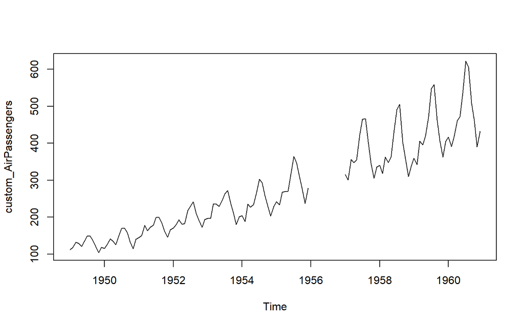

```r
# Plot the custom_AirPassengers data
plot(custom_AirPassengers)
```

```r
# Compute the mean of AirPassengers
mean(custom_AirPassengers, na.rm=T)
```

```
## [1] 275.9394
```

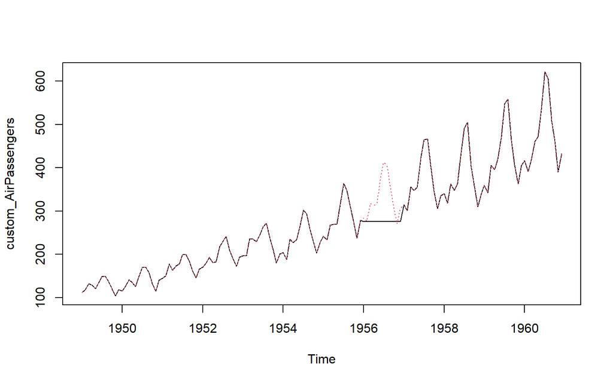

```r
# Impute mean values to NA in AirPassengers
custom_AirPassengers[is.na(custom_AirPassengers)] <- mean(custom_AirPassengers, na.rm = T)

# Generate another plot of AirPassengers
plot(custom_AirPassengers)

# Add the complete AirPassengers data to your plot

points(AirPassengers, type = "l", col = 2, lty = 3)
```

# Diagnostic checklist

When looking at a time series plot, ask:

1. Is the **level** changing over time?
2. Is the **variability** changing?
3. Is there a repeating **seasonal pattern**?
4. Do nearby observations appear **dependent**?
5. Are there unusual **outliers** or missing values?

These questions guide the choice of transformation and model.

# Trend spotting!

# Random or not random?

Some time series exhibit predictability when strong periodic or seasonal patterns are present. Other time series exhibit predictability when positive autocorrelation - or correlation among neighboring observations - induces what appear as short-term trends.

**Examine the time series plots below. Which pair of time series do NOT appear predictable?**

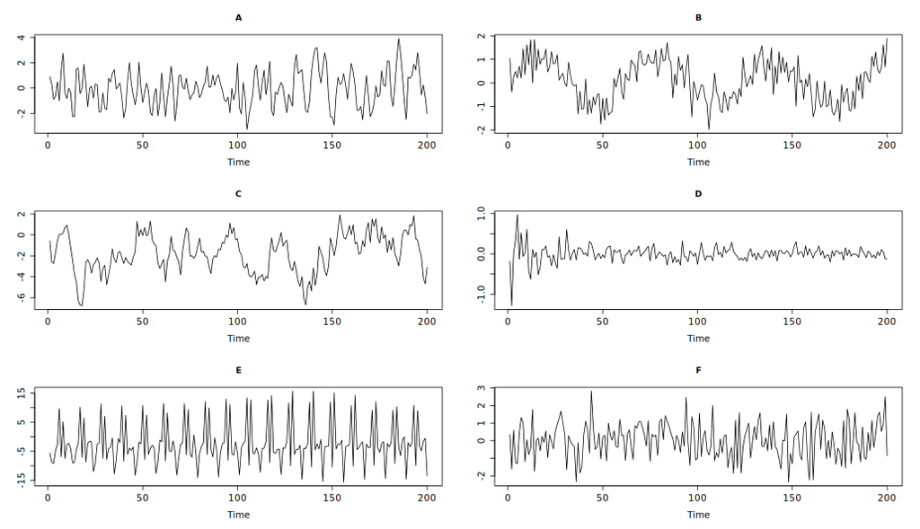

# Name that trend

Common types of trends in time series data include persistent growth or decay over time, increasing variability over time, and periodic or seasonal patterns, that is regularly spaced peaks and troughs appearing throughout the data.

**Which time series exhibits an approximately linear growth pattern over time?**

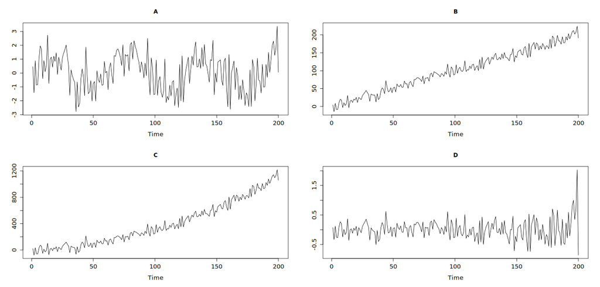

- **Answer:** $\checkmark$ B

# Removing trends in variability via the logarithmic transformation

The logarithmic function `log()` is a data transformation that can be applied to positively valued time series data. It slightly shrinks observations that are greater than one towards zero, while greatly shrinking very large observations. This property can stabilize variability when a series exhibits increasing variability over time. It may also be used to linearize a rapid growth pattern over time.

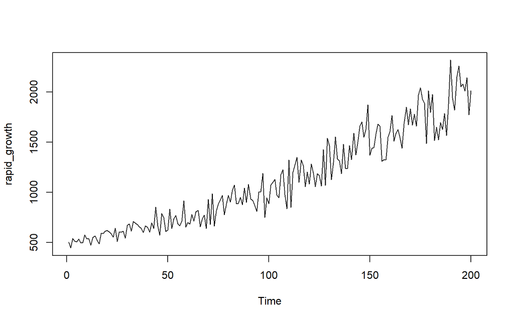

```r
x <- c(
  505.9547, 447.3556, 542.5831, 516.0634, 506.9599, 535.0162, 496.9291,
  497.5626, 577.2483, 536.8560, 541.2459, 473.4978, 550.9890, 569.4106,
  522.9152, 487.2002, 594.6108, 591.1740, 615.9868, 621.3175, 607.1250,
  587.0367, 554.1554, 644.1172, 509.7000, 607.0943, 603.5512, 613.6216,
  544.9143, 670.8118, 687.1316, 615.5817, 711.1873, 694.2979, 681.9293,
  659.1403, 642.7021, 601.5301, 666.7623, 650.9657, 606.0913, 696.6788,
  641.6025, 855.7719, 667.3291, 573.4914, 791.7333, 751.5914, 610.7948,
  624.6503, 833.2990, 639.8867, 736.8283, 772.2923, 686.8865, 667.7631,
  712.9415, 918.1838, 656.1089, 700.4972, 683.4933, 781.7380, 715.6843,
  808.2875, 820.7795, 656.8856, 733.3400, 773.5387, 641.2027, 932.2119,
  680.6766, 988.2828, 664.8986, 813.5283, 883.4088, 924.2749, 969.4321,
  777.3293, 880.9984, 971.3583, 902.9584, 1020.7457, 1075.1483, 886.1707,
  889.6322, 950.3908, 878.0395, 1043.7676, 901.1090, 1079.6584, 933.9054,
  921.9433, 870.8071, 811.1398, 1004.2677, 1008.1758, 1189.4893, 751.9706,
  947.4753, 886.5153, 1074.8943, 1101.1307, 1130.1855, 975.8495, 948.1610,
  1177.8227, 1227.1271, 976.9957, 836.7089, 1323.6047, 852.3532, 1200.8262,
  1274.4788, 1349.2614, 1102.6334, 1324.8566, 1268.7187, 1058.2289, 1204.0872,
  1084.6503, 1284.4305, 1195.2843, 1058.4262, 1188.0577, 1166.5934, 1064.6946,
  1429.0685, 1070.8528, 1539.3305, 1467.1571, 1127.7058, 1296.0717, 1555.2741,
  1332.9037, 1315.4236, 1189.2462, 1482.4339, 1240.9287, 1237.7720, 1468.6083,
  1328.5457, 1589.5078, 1373.1630, 1503.5563, 1659.9376, 1704.6137, 1550.4638,
  1625.8026, 1873.8582, 1370.6209, 1439.7114, 1447.4369, 1579.9158, 1681.2571,
  1661.6059, 1311.8468, 1326.0308, 1323.0995, 1550.4863, 1606.2042, 1768.5401,
  1509.8368, 1592.1086, 1627.6188, 1544.6329, 1439.5234, 1682.3518, 1850.7097,
  1673.3801, 1832.4272, 1672.2672, 1781.5768, 1659.2899, 1970.0389, 2044.7124,
  1929.0902, 1891.7042, 1487.1577, 2013.8722, 1796.7886, 1977.0183, 1516.9552,
  1650.6039, 1523.2834, 1696.6181, 1627.2609, 1787.2968, 1567.2874, 1881.9963,
  2318.9833, 1941.9879, 1820.2797, 2154.8123, 2261.5471, 2052.2214, 2079.1710,
  2010.0609, 2145.2606, 1775.3008, 2013.4070
)

rapid_growth <- ts(data = x,
                   start = c(1, 1),
                   frequency = 1)
ts.plot(rapid_growth)
```

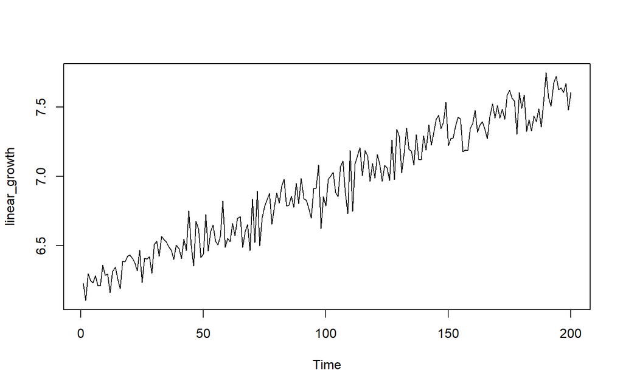

```r
# Log rapid_growth
linear_growth <- log(rapid_growth)

# Plot linear_growth using ts.plot()

 ts.plot(linear_growth)
```

# Removing trends in level by differencing

The first difference transformation of a time series consists of the differences (changes) between successive observations over time, that is z[t] - z[t-1].

Differencing a time series can remove a time trend. The function `diff()` will calculate the first difference or change series. A difference series lets you examine the increments or changes in a given time series. It always has one fewer observations than the original series.

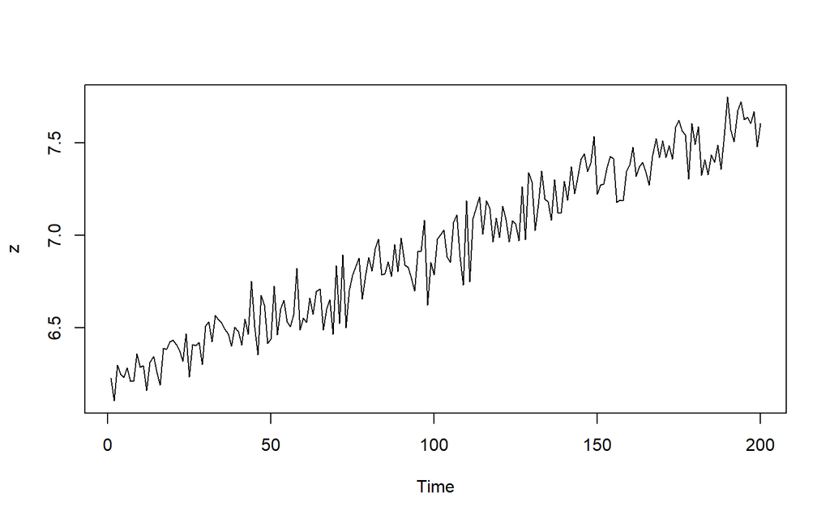

```r
z <- c(
  6.226447, 6.103354, 6.296341, 6.246230, 6.228432, 6.282297, 6.208447, 6.209721,
  6.358273, 6.285730, 6.293874, 6.160147, 6.311715, 6.344602, 6.259419, 6.188675,
  6.387907, 6.382110, 6.423225, 6.431842, 6.408735, 6.375087, 6.317445, 6.467881,
  6.233822, 6.408684, 6.402831, 6.419378, 6.300629, 6.508489, 6.532526, 6.422568,
  6.566936, 6.542901, 6.524926, 6.490936, 6.465681, 6.399477, 6.502434, 6.478457,
  6.407031, 6.546325, 6.463969, 6.752004, 6.503283, 6.351743, 6.674225, 6.622193,
  6.414761, 6.437192, 6.725393, 6.461291, 6.602355, 6.649363, 6.532169, 6.503933,
  6.569399, 6.822398, 6.486327, 6.551790, 6.527217, 6.661520, 6.573239, 6.694918,
  6.710255, 6.487510, 6.597609, 6.650976, 6.463346, 6.837560, 6.523087, 6.895969,
  6.499635, 6.701381, 6.783788, 6.829010, 6.876710, 6.655864, 6.781056, 6.878695,
  6.805677, 6.928289, 6.980214, 6.786910, 6.790808, 6.856873, 6.777692, 6.950592,
  6.803626, 6.984400, 6.839375, 6.826484, 6.769420, 6.698440, 6.912014, 6.915898,
  7.081279, 6.622697, 6.853801, 6.787298, 6.979978, 7.004093, 7.030137, 6.883308,
  6.854524, 7.071423, 7.112431, 6.884482, 6.729476, 7.188114, 6.748001, 7.090765,
  7.150293, 7.207313, 7.005457, 7.189060, 7.145763, 6.964352, 7.093477, 6.989013,
  7.158071, 7.086139, 6.964538, 7.080075, 7.061843, 6.970443, 7.264778, 6.976211,
  7.339103, 7.291082, 7.027941, 7.167093, 7.349407, 7.195115, 7.181914, 7.081075,
  7.301441, 7.123615, 7.121068, 7.292071, 7.191840, 7.371180, 7.224872, 7.315588,
  7.414535, 7.441094, 7.346309, 7.393757, 7.535755, 7.223019, 7.272198, 7.277550,
  7.365127, 7.427297, 7.415540, 7.179191, 7.189945, 7.187732, 7.346324, 7.381629,
  7.477910, 7.319757, 7.372815, 7.394873, 7.342542, 7.272067, 7.427948, 7.523324,
  7.422601, 7.513397, 7.421936, 7.485254, 7.414145, 7.585809, 7.623012, 7.564804,
  7.545233, 7.304622, 7.607815, 7.493756, 7.589345, 7.324460, 7.408897, 7.328623,
  7.436392, 7.394653, 7.488460, 7.357102, 7.540088, 7.748884, 7.571467, 7.506745,
  7.675459, 7.723804, 7.626678, 7.639725, 7.605920, 7.671016, 7.481725, 7.607584
)
z <- ts(data = z,
        start = c(1, 1),
        frequency = 1)

ts.plot(z)
```

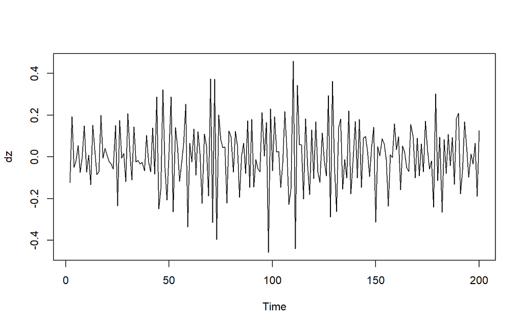

```r
# Generate the first difference of z
dz <- diff(z)

# Plot dz
ts.plot(dz)
```

```r
# View the length of z and dz, respectively

length(z)
```

```
## [1] 200
```

```r
length(dz)
```

```
## [1] 199
```

**By removing the long-term time trend, you can view the amount of change from one observation to the next.**

# Removing seasonal trends with seasonal differencing

For time series exhibiting seasonal trends, seasonal differencing can be applied to remove these periodic patterns. For example, monthly data may exhibit a strong twelve month pattern. In such situations, changes in behavior from year to year may be of more interest than changes from month to month, which may largely follow the overall seasonal pattern.

The function `diff(..., lag = s)` will calculate the lag `s` difference or length `s` seasonal change series. For monthly or quarterly data, an appropriate value of `s` would be 12 or 4, respectively. The `diff()` function has `lag = 1` as its default for first differencing. Similar to before, a seasonally differenced series will have `s` fewer observations than the original series.

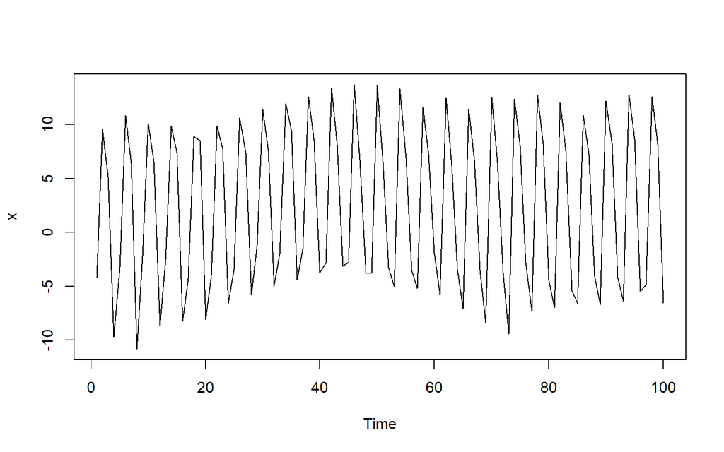

```r
x <- c(
  -4.198033, 9.569009, 5.175143, -9.691646, -3.215294, 10.843669,
  6.452159, -10.833559, -2.235351, 10.119833, 6.579646, -8.656565,
  -2.515001, 9.837434, 7.386194, -8.243504, -4.264033, 8.898861,
  8.544336, -8.066913, -4.023025, 9.822679, 7.772852, -6.587777,
  -3.459171, 10.613851, 7.374450, -5.798715, -1.204711, 11.429236,
  7.570047, -4.968384, -2.003787, 11.941348, 9.406672, -4.396585,
  -1.555579, 12.599877, 8.502916, -3.728968, -2.827000, 13.375981,
  8.128941, -3.149249, -2.799473, 13.710570, 6.755217, -3.779744,
  -3.768274, 13.625336, 6.537931, -3.249098, -5.024191, 13.355373,
  6.931161, -3.527354, -5.197329, 11.579791, 7.162449, -1.894607,
  -5.777797, 12.482695, 6.208088, -3.434038, -7.080721, 11.413656,
  6.741990, -3.532376, -8.393542, 12.507261, 6.473175, -3.745246,
  -9.426209, 12.380817, 8.048243, -2.831528, -7.301893, 12.765838,
  8.223699, -4.448131, -6.963558, 12.034005, 7.574925, -5.402218,
  -6.568198, 10.896482, 7.276571, -4.037873, -6.723013, 12.180815,
  8.285162, -4.159342, -6.360670, 12.753018, 8.665912, -5.440538,
  -4.874932, 12.600197, 8.162589, -6.539572
)

x <- ts(data = x,
        start = c(1, 1),
        frequency = 1)
ts.plot(x)
```

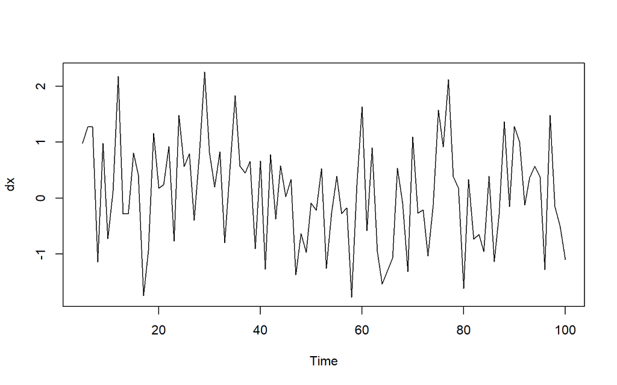

```r
# Generate a diff of x with lag = 4. Save this to dx
dx <- diff(x, lag = 4)

# Plot dx
ts.plot(dx)
```

```r
# View the length of x and dx, respectively

length(x)
```

```
## [1] 100
```

```r
length(dx)
```

```
## [1] 96
```

**Once again differencing allows you to remove the longer-term time trend - in this case, seasonal volatility - and focus on the change from one period to another.**

# White-noise checklist

A weak white-noise process has:

- constant mean,
- constant variance,
- zero autocorrelation at non-zero lags.

A useful diagnostic is whether the ACF is essentially zero beyond lag 0.

# The White noise (WN) model

# White noise

White Noise (WN) is the simplest example of a stationary process.

**A weak white noise process has:**

- A fixed, constant mean.
- A fixed, constant variance.
- No correlation over time

**Time series plots of White Noise:**

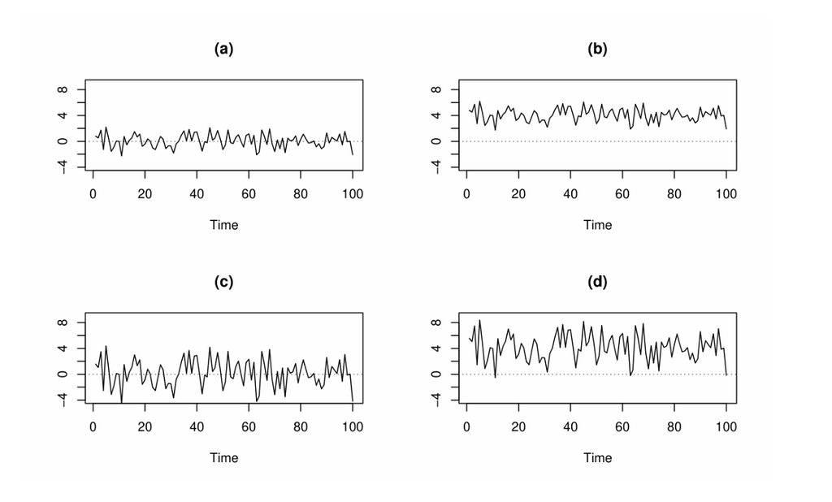

**Time series plots of White Noise?**

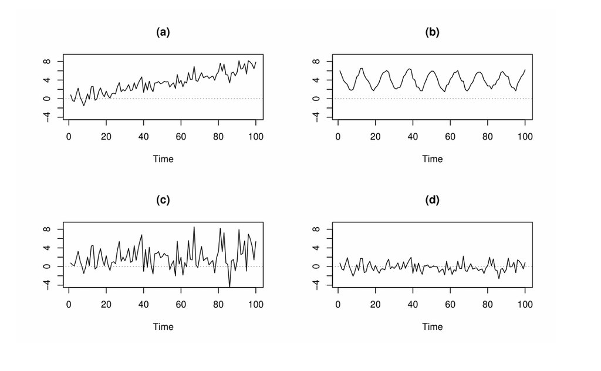

**Answer:** $\checkmark$ d.

# Simulate the white noise model

The white noise (WN) model is a basic time series model. It is also a basis for the more elaborate models we will consider. We will focus on the simplest form of WN, independent and identically distributed data.

The `arima.sim()` function can be used to simulate data from a variety of time series models. ARIMA is an abbreviation for the **autoregressive integrated moving average** class of models we will consider throughout this course.

An **ARIMA(p, d, q)** model has three parts, the autoregressive order `p`, the order of integration (or differencing) `d`, and the moving average order `q`. We will detail each of these parts soon, but for now we note that the **ARIMA(0, 0, 0)** model, i.e., with all of these components zero, is simply the WN model.

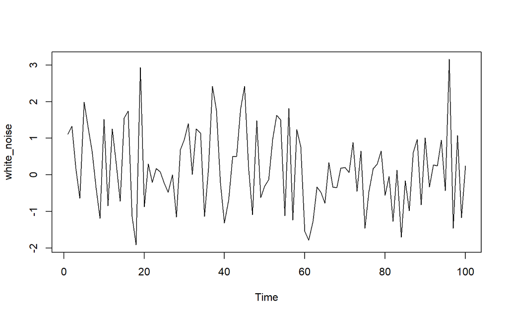

```r
# Simulate a WN model with list(order = c(0, 0, 0))
white_noise <- arima.sim(model = list(order = c(0, 0, 0)), n = 100)

# Plot your white_noise data
ts.plot(white_noise)
```

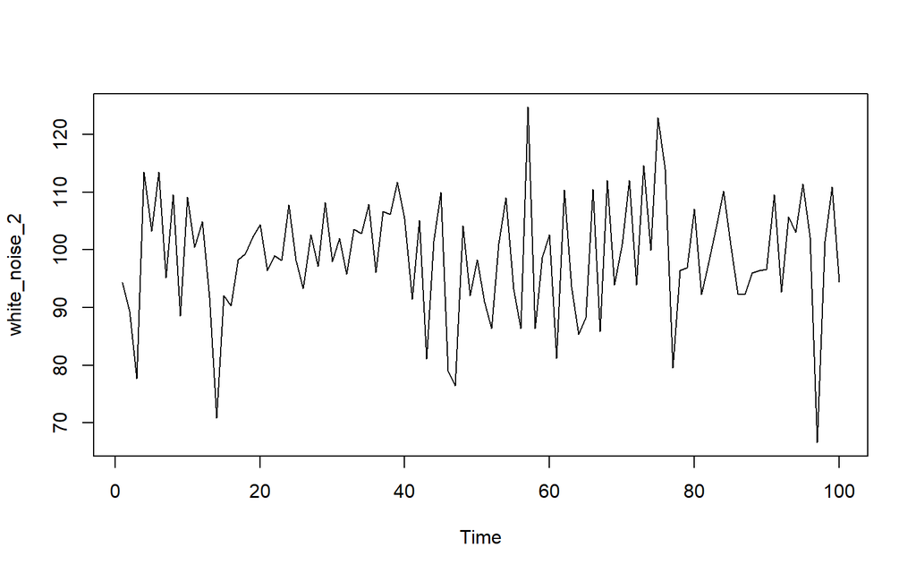

```r
# Simulate from the WN model with: mean = 100, sd = 10
white_noise_2 <- arima.sim(model = list(order = c(0, 0, 0)), n = 100, mean = 100, sd = 10)

# Plot your white_noise_2 data
ts.plot(white_noise_2)
```

# Estimate the white noise model

For a given time series y we can fit the white noise (WN) model using the `arima(..., order = c(0, 0, 0))` function. Recall that the WN model is an **ARIMA(0,0,0)** model. Applying the `arima()` function returns information or output about the estimated model. For the WN model this includes the estimated mean, labeled `intercept`, and the estimated variance, labeled `sigma^2`.

In this exercise, you’ll explore the qualities of the WN model. What is the estimated mean? Compare this with the sample mean using the mean() function. What is the estimated variance? Compare this with the sample variance using the `var()` function.

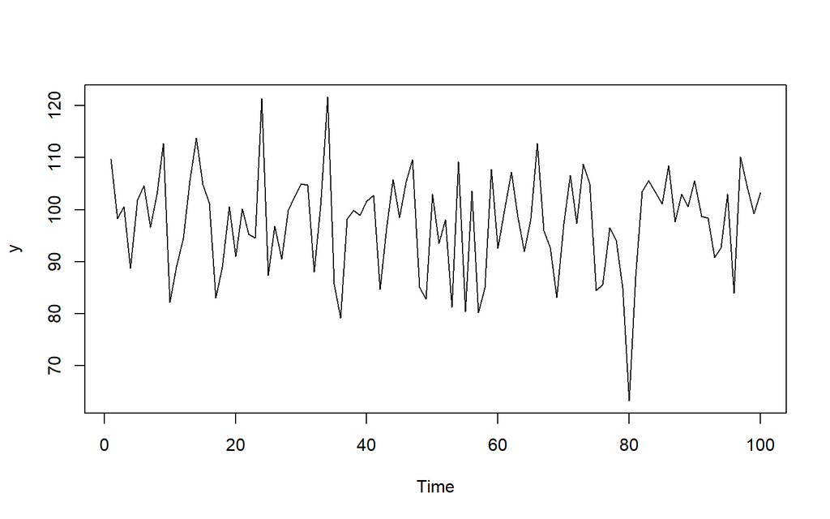

```r
x <- c(
  109.76134, 98.31610, 100.63295, 88.74340, 101.87238, 104.62836, 96.64462,
  102.86194, 112.76247, 82.23219, 88.94434, 94.60318, 105.61113, 113.82776,
  104.82319, 101.29629, 82.98459, 88.96058, 100.60046, 91.03525, 100.19286,
  95.32537, 94.58643, 121.35830, 87.37874, 96.89007, 90.51310, 99.90843,
  102.56934, 104.96144, 104.73464, 88.00465, 100.77943, 121.64776, 85.77083,
  79.15428, 98.18847, 99.90006, 98.91084, 101.64422, 102.79526, 84.65112,
  96.47870, 105.81547, 98.51869, 105.24366, 109.61264, 85.14201, 82.81442,
  103.03629, 93.56967, 98.08922, 81.25461, 109.18554, 80.43181, 103.55953,
  80.22269, 84.97477, 107.78363, 92.61288, 99.80293, 107.25085, 98.66378,
  91.92275, 98.32642, 112.73402, 96.02811, 92.64909, 83.08484, 97.22196,
  106.61361, 97.36943, 108.78465, 104.91858, 84.44343, 85.60786, 96.51529,
  94.18105, 85.02851, 63.26622, 87.22137, 103.52295, 105.60216, 103.26039,
  101.11519, 108.45697, 97.67631, 103.01081, 100.61756, 105.58108, 98.72722,
  98.43996, 90.78219, 92.74599, 102.93762, 83.95306, 110.15937, 104.17578,
  99.27876, 103.25115
)
y <- ts(data = x, start = c(1, 1), frequency = 1)
ts.plot(y)
```

```r
# Fit the WN model to y using the arima command
arima(y, order = c(0, 0, 0))
```

```
##
## Call:
## arima(x = y, order = c(0, 0, 0))
##
## Coefficients:
##       intercept
##         97.5428
## s.e.     0.9697
##
## sigma^2 estimated as 94.03:  log likelihood = -369.08,  aic = 742.15
```

```r
# Calculate the sample mean and sample variance of y
mean(y)
```

```
## [1] 97.54284
```

```r
var(y)
```

```
## [1] 94.98174
```

# Random-walk checklist

A random walk is characterized by:

- non-stationary level,
- strong persistence,
- changes that behave like white noise.

> **Key relationship:** If `Y_t = Y_{t-1} + ε_t`, then `diff(Y)` is white noise.

# The random walk (RW) model

# Random walk

Random Walk (RW) is a simple example of a non-stationary process.

A random walk has:

- No specified mean or variance.
- Strong dependence over time.
- Its changes or increments are white noise (WN).

**Time series plots of Random Walk:**

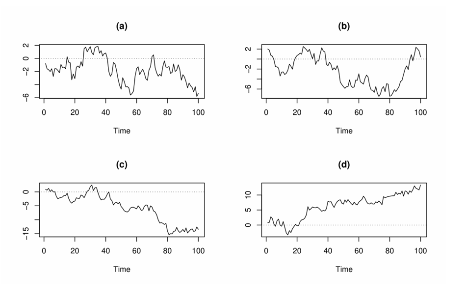

**The random walk recursion:**

$$Today = Yesterday + Noise$$

More formally:

$$Y_t = Y_{t-1} + \epsilon_t$$

where $\epsilon_t$ is mean zero white noise (WN).

- Simulation requires an initial point $Y_0$.
- Only one parameter, the WN variance $\sigma^2_{\epsilon}$.

As $Y_t - Y_{t-1} = \epsilon_t \rightarrow$ diff(Y) is WN

**Random walk**

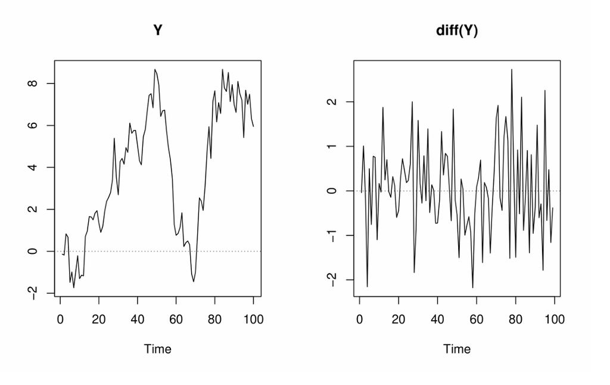

**Random walk with drift**

The random walk with a drift:

$$Today = Constant+Yesterday
+Noise$$

More formally:

$$Y_t = c + Y_{t-1} + \epsilon_t$$

where $\epsilon_t$is mean zero white noise (WN).

- Two parameters, the constant c, and the WN variance $\sigma^2_{\epsilon}$.
- $Y_t - Y_{t-1} = ? \rightarrow$ WN with mean c!

**Time series plots of Random Walk with drift:**

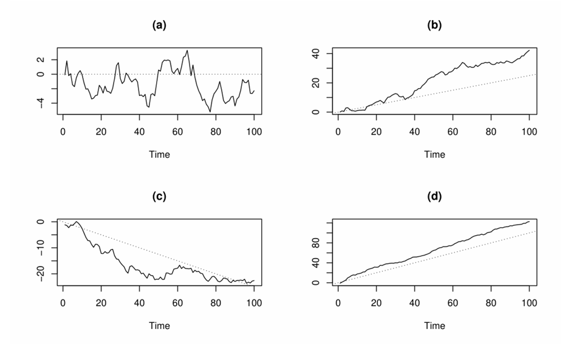

**Main difference between random walk model with and without drift**

| Feature | Random Walk Without Drift | Random Walk With Drift |
| --- | --- | --- |
| Model | $Y_t=Y_{t-1}+\varepsilon_t$ | $Y_t=c+Y_{t-1}+\varepsilon_t$ |
| Drift term | No | Yes |
| Expected change | $0$ | $c$ |
| Systematic trend | No | Yes, on average |
| If $c>0$ | — | Upward tendency |
| If $c<0$ | — | Downward tendency |

# Simulate the random walk model

The random walk (RW) model is also a basic time series model. It is the cumulative sum (or integration) of a mean zero white noise (WN) series, such that the first difference series of a RW is a WN series. Note for reference that the RW model is an **ARIMA(0, 1, 0)** model, in which the middle entry of 1 indicates that the model’s order of integration is 1.

The `arima.sim()` function can be used to simulate data from the RW by including the `model = list(order = c(0, 1, 0))` argument. We also need to specify a series length `n`. Finally, you can specify a `sd` for the series (increments), where the default value is 1.

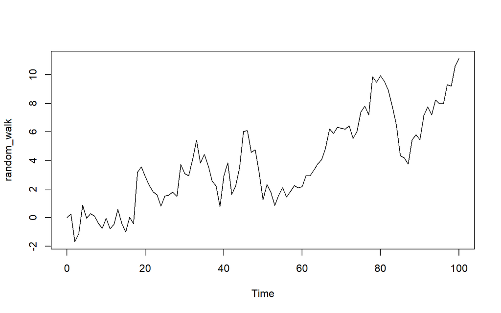

```r
# Generate a RW model using arima.sim
random_walk <- arima.sim(model = list(order = c(0, 1, 0)), n = 100)

# Plot random_walk
ts.plot(random_walk)
```

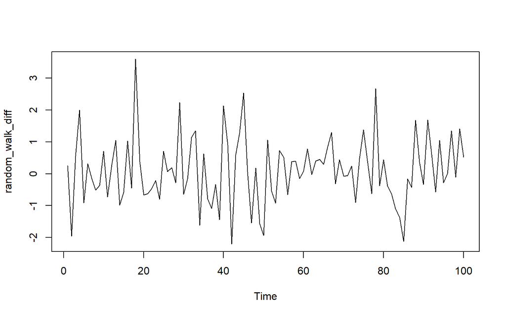

```r
# Calculate the first difference series
random_walk_diff <- diff(random_walk)

# Plot random_walk_diff

  ts.plot(random_walk_diff)
```

# Simulate the random walk model with a drift

A random walk (RW) need not wander about zero, it can have an upward or downward trajectory, i.e., a drift or time trend. This is done by including an intercept in the RW model, which corresponds to the slope of the RW time trend.

For an alternative formulation, you can take the cumulative sum of a constant mean white noise (WN) series, such that the mean corresponds to the slope of the RW time trend.

To simulate data from the RW model with a drift you again use the `arima.sim()` function with the `model = list(order = c(0, 1, 0))` argument. This time, you should add the additional argument `mean = ...` to specify the drift variable, or the intercept.

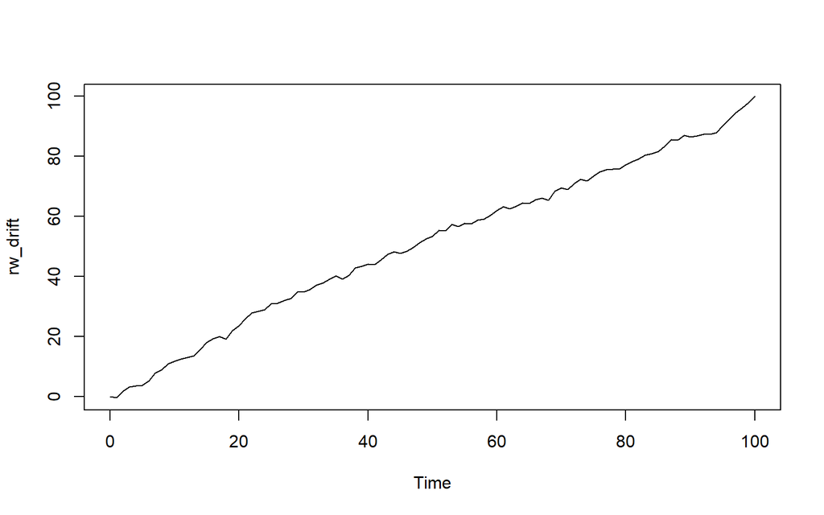

```r
# Generate an RW model with a drift using arima.sim
rw_drift <- arima.sim(model = list(order = c(0, 1, 0)), n = 100, mean = 1)

# Plot rw_drift
ts.plot(rw_drift)
```

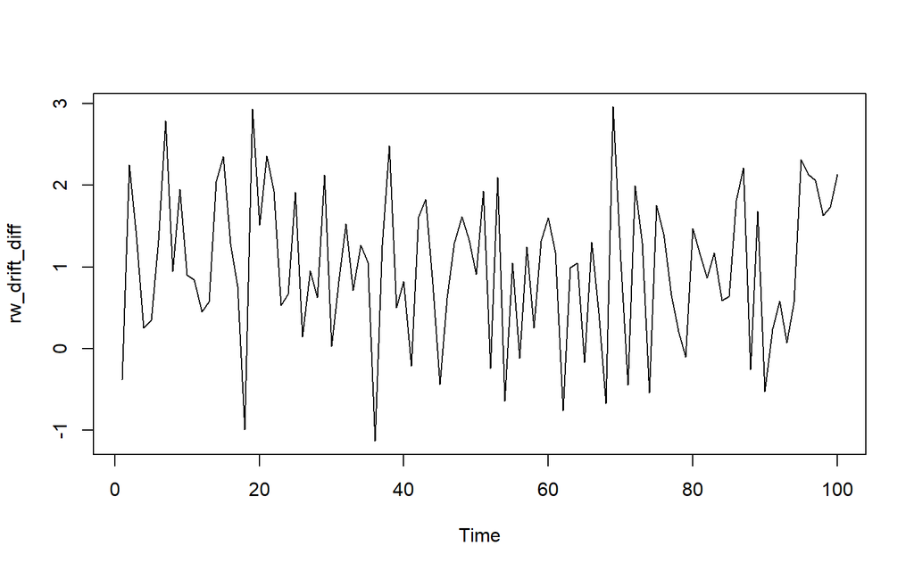

```r
# Calculate the first difference series
rw_drift_diff <- diff(rw_drift)

# Plot rw_drift_diff

ts.plot(rw_drift_diff)
```